# Workshop on Sample Size Planning in N=1 Intensive Longitudinal (IL) Designs

Ginette Lafit (ginette.lafit@kuleuven.be) & Jordan Revol (jordan.revol@kuleuven.be)

25 mei, 2023

# Preliminaries

## Prelim - Installing libraries used in this script (if necessary)

```r
# This code chunk simply makes sure that all the
# libraries used here are installed.
# Check if R packages are installed
## Do not run because we do not want to install packages (this should be your decision)

list.of.packages = c("data.table","psych","ggplot2","tidyverse","MASS")
new.packages = list.of.packages[!(list.of.packages %in% installed.packages()[,"Package"])]
if(length(new.packages)) install.packages(new.packages)
```

### Upload libraries to be used in the analysis

```r
library(data.table) # to create lagged outcome
library(psych) # to compute descriptive statistics
library(ggplot2) # for making plots
library(tidyverse) # a useful package

library(MASS)

set.seed(1235) # Set a seed to reproduce analyses
```

# Illustrative data set: Leuven clinical study

We use data from Heininga et al. (2019); this study applies the ESM methodology to study emotion dynamics in people with Major Depressive Disorder. The study consist of an ESM testing period of 7 days in which participants had to fill out questions about mood and social context on their daily lives ten times a day (i.e., 70 measurement occasions). The data set contains 38 participants diagnosed with MDD and 40 control subjects. Participants filled out the ESM questionnaires in a stratified random interval scheme between 9:30 AM and 9:30 PM.

First, we are going to load the data set:

```r
# Load data set
load(file="data/Clinical_Dataset.RData")

# Select the first participant diagnosed with major depressive
i.ID = unique(data$PID[data$MDD==1])[1]

# Select data from participant with person identification number PID=101
data = data[data$PID==101,]

# Find the dimensions
dim(data)
```

```
## [1] 70  8
```

```r
# Find the structure
str(data)
```

```
## 'data.frame':    70 obs. of  8 variables:
##  $ PID      : num  101 101 101 101 101 101 101 101 101 101 ...
##  $ day      : num  1 1 1 1 1 1 1 1 1 1 ...
##  $ daybeep  : num  1 2 3 4 5 6 7 8 9 10 ...
##  $ PA       : num  NA 27.3 49.7 43 43 ...
##  $ NA.      : num  NA 30.4 23.8 24.2 32.8 19.6 18.4 21.2 23 21.8 ...
##  $ anhedonia: num  NA 26 25 25 50 21 42 30 22 30 ...
##  $ MDD      : num  1 1 1 1 1 1 1 1 1 1 ...
##  $ QIDS     : num  12 12 12 12 12 12 12 12 12 12 ...
```

```r
# See the first 6 rows
head(data)
```

```
##   PID day daybeep       PA  NA. anhedonia MDD QIDS
## 1 101   1       1       NA   NA        NA   1   12
## 2 101   1       2 27.33333 30.4        26   1   12
## 3 101   1       3 49.66667 23.8        25   1   12
## 4 101   1       4 43.00000 24.2        25   1   12
## 5 101   1       5 43.00000 32.8        50   1   12
## 6 101   1       6 18.00000 19.6        21   1   12
```

```r
# See the last 6 rows
tail(data)
```

```
##    PID day daybeep       PA  NA. anhedonia MDD QIDS
## 65 101   7       5 24.33333 31.8        52   1   12
## 66 101   7       6 28.66667 20.6        53   1   12
## 67 101   7       7 23.33333 23.8        51   1   12
## 68 101   7       8 33.66667 36.2        46   1   12
## 69 101   7       9 41.66667 21.0        29   1   12
## 70 101   7      10 34.00000 18.4        47   1   12
```

```r
# Find the column names
names(data)
```

```
## [1] "PID"       "day"       "daybeep"   "PA"        "NA."       "anhedonia"
## [7] "MDD"       "QIDS"
```

```r
# Summary of the data
summary(data)
```

```
##       PID           day       daybeep           PA             NA.
##  Min.   :101   Min.   :1   Min.   : 1.0   Min.   :14.67   Min.   :14.40
##  1st Qu.:101   1st Qu.:2   1st Qu.: 3.0   1st Qu.:26.08   1st Qu.:21.40
##  Median :101   Median :4   Median : 5.5   Median :33.33   Median :25.90
##  Mean   :101   Mean   :4   Mean   : 5.5   Mean   :33.51   Mean   :29.62
##  3rd Qu.:101   3rd Qu.:6   3rd Qu.: 8.0   3rd Qu.:41.67   3rd Qu.:36.25
##  Max.   :101   Max.   :7   Max.   :10.0   Max.   :57.33   Max.   :65.60
##                                           NA's   :6       NA's   :6
##    anhedonia          MDD         QIDS
##  Min.   :14.00   Min.   :1   Min.   :12
##  1st Qu.:24.75   1st Qu.:1   1st Qu.:12
##  Median :41.50   Median :1   Median :12
##  Mean   :39.34   Mean   :1   Mean   :12
##  3rd Qu.:52.00   3rd Qu.:1   3rd Qu.:12
##  Max.   :83.00   Max.   :1   Max.   :12
##  NA's   :6
```

```r
# Number of participants
length(unique(data$PID))
```

```
## [1] 1
```

The data set contains the following variables: `PID` that denotes the individual identification number, `day` is a variable that ranges from 1 to 7 and identifies the day of ESM testing, `daybeep` is a variable that ranges from 1 to 10 and identifies the number of the prompt or beep within a day. `PA` is the Positive Affect computed as the mean of items: ‘How happy do you feel at the moment?’, ‘How relaxed do you feel at the moment?’ and ‘How euphoric do you feel at the moment?’. `NA.` is the Negative Affect computed as the mean of items: ‘How depressed do you feel at the moment?’, ‘How stressed do you feel at the moment?’, ‘How anxious do you feel at the moment?’, ‘How angry do you feel at the moment?’ and ‘How restless do you feel at the moment?’. `anhedonia` corresponds to the ESM item ‘To what degree do you find it difficult to experience pleasure in activities at the moment?’. `MDD` is a dummy variable equal to one when the individual has been diagnosed with MDD and 0 otherwise, finally `QIDS` denotes the sum of the items of the Quick Inventory of Depressive Symptomatology (i.e. QIDS) [@rush200316]. QIDS was measured before the ESM testing period. Time-varying variables (PA, NA, and anhedonia) have been lagged within days to account for the night breaks.

## Visulations and descriptive statistics

We first obtain some descriptive statistics including number of observations per day, and compliance.

```r
# Get the number of assessment per day
table(data$PID)
```

```
##
## 101
##  70
```

```r
# Compute a binary variable indicating if a participant answered a beep. We take the ESM item PA as reference because in this ESM design participants were not allowed to skip items
data$Compliance = ifelse(is.na(data$PA)==FALSE, 1, 0)

# Mean, median of the compliance for the participant PID=101
describe(data$Compliance)
```

```
##    vars  n mean   sd median trimmed mad min max range skew kurtosis   se
## X1    1 70 0.91 0.28      1       1   0   0   1     1 -2.9     6.48 0.03
```

Next, we can obtain visualizations and statistics of the distribution of the person-level or time-invariant variables variables

```r
# We create a data set that will aggregate the data from the time invariant variables: diagnosis (1 = MDD, 0 = control) and depression (QIDS)
dt.person = aggregate(cbind(data$MDD,data$QIDS), by = list(data$PID), mean, na.rm = TRUE)
colnames(dt.person) = c("Group.1","MDD","QIDS")
dt.person
```

```
##   Group.1 MDD QIDS
## 1     101   1   12
```

We now focus on time-varying variables NA, PA, and anhedonia and we obtain visualization and descriptive statistics

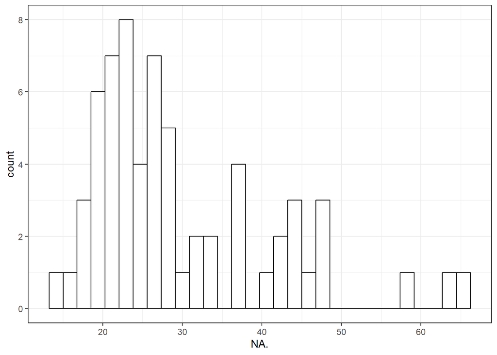

```r
# Histogram for the time-varying variable negative affect (NA.)
ggplot(data, aes(NA.)) + geom_histogram(color="black", fill="white",bins=30) + theme_bw()
```

```r
# Descriptive statistics for NA.
describe(data$NA.)
```

```
##    vars  n  mean    sd median trimmed  mad  min  max range skew kurtosis   se
## X1    1 64 29.62 11.47   25.9   28.13 7.86 14.4 65.6  51.2 1.25     1.01 1.43
```

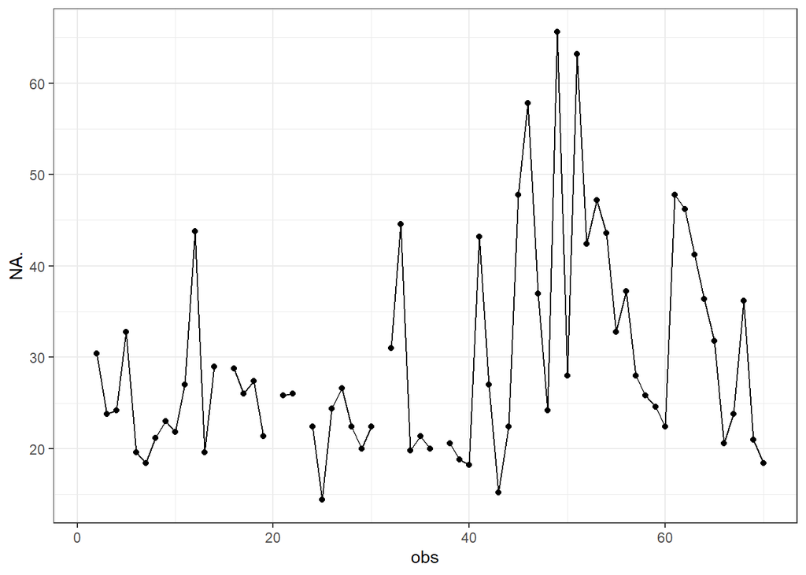

```r
# Create obs order variable
data$obs = 1:nrow(data)

# Plot the trajectories of the time-varying variable NA by person
data %>%
  ggplot(aes(x = obs, y = NA.)) +
  geom_point() +
  geom_line() + theme_bw()
```

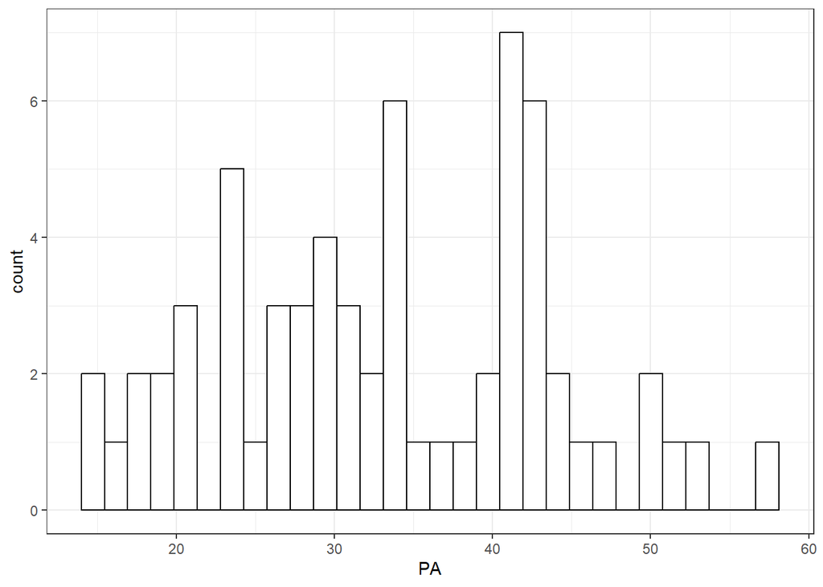

```r
# Histogram for the time-varying variable negative affect (PA)
ggplot(data, aes(PA)) + geom_histogram(color="black", fill="white",bins=30) + theme_bw()
```

```r
# Descriptive statistics for PA
describe(data$PA)
```

```
##    vars  n  mean    sd median trimmed   mad   min   max range skew kurtosis
## X1    1 64 33.51 10.32  33.33   33.33 12.35 14.67 57.33 42.67 0.09    -0.84
##      se
## X1 1.29
```

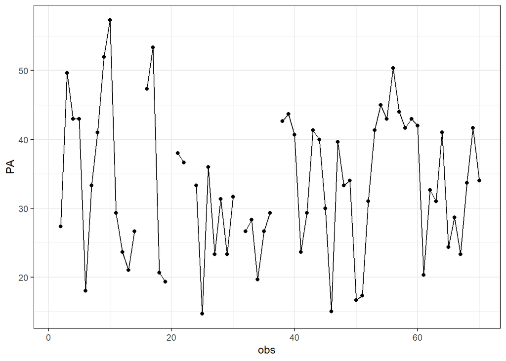

```r
# Plot the trajectories of the time-varying variable PA by person
data %>%
  ggplot(aes(x = obs, y = PA)) +
  geom_point() +
  geom_line() + theme_bw()
```

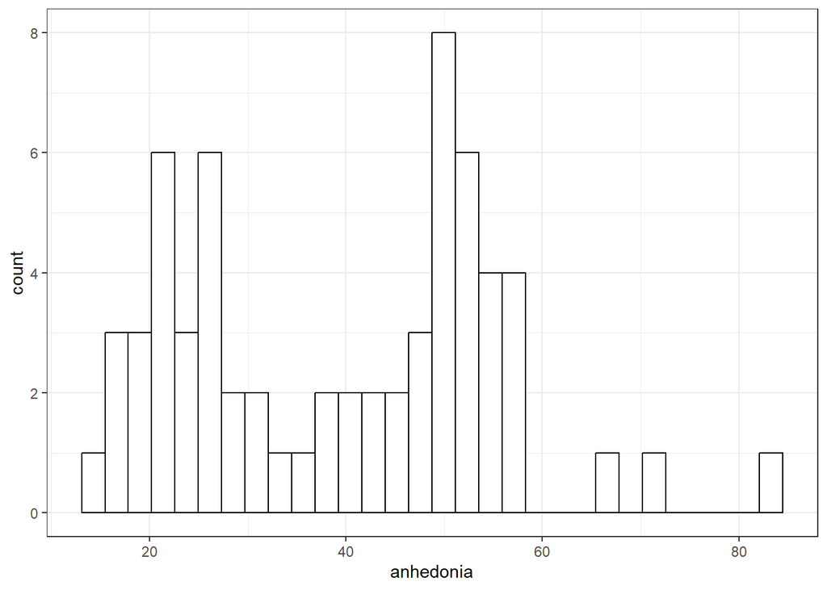

```r
# Histogram for the time-varying variable anhedonia
ggplot(data, aes(anhedonia)) + geom_histogram(color="black", fill="white",bins=30) + theme_bw()
```

```r
# Descriptive statistics for anhedonia
describe(data$anhedonia)
```

```
##    vars  n  mean    sd median trimmed   mad min max range skew kurtosis   se
## X1    1 64 39.34 15.84   41.5   38.92 20.02  14  83    69 0.22    -0.77 1.98
```

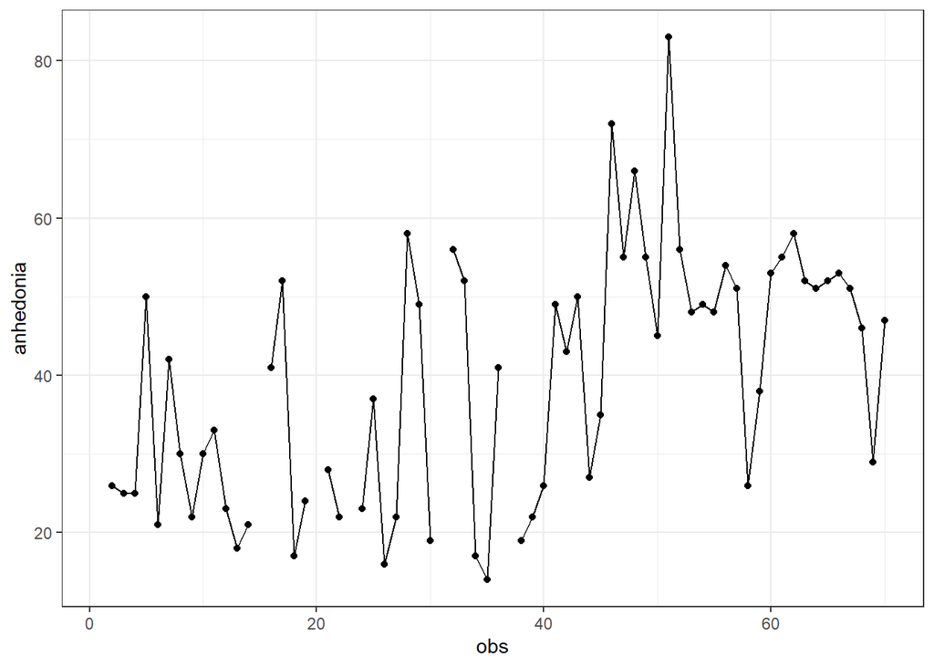

```r
# Plot the trajectories of the time-varying variable anhedonia by person
data %>%
  ggplot(aes(x = obs, y = anhedonia)) +
  geom_point() +
  geom_line() + theme_bw()
```

Finally, we create the lagged variables for PA and NA. They will be used on the following AR(1) and VAR(1) models.

```r
# Create lagged variables: lagged within days to take into account night breaks
data$PA.lag = rep(NA,nrow(data))
data$NA.lag = rep(NA,nrow(data))
data$anhedonia.lag = rep(NA,nrow(data))
day.id = unique(data$day)
for (t in day.id){
  data$PA.lag[which(data$day==t)] = shift(data$PA[which(data$day==t)],1)
  data$NA.lag[which(data$day==t)] = shift(data$NA.[which(data$day==t)],1)
  data$anhedonia.lag[which(data$day==t)] = shift(data$anhedonia[which(data$day==t)],1)
}
```

# Example 1: Estimate autoregressive AR(1) model for PA

We estimate an AR(1) model for PA using a linear regression model (ordinary least squares, OLS). You can extract the estimates with the ‘summary()’ function. Finally, you can compute the estimate of the standard deviation of the errors of the AR(1) model computing the standard deviation using the function ‘sd()’ on the residuals of the fitted model.

```r
# AR(1) model for PA
fit.AR.PA = lm(PA ~ 1 + PA.lag, data = data)
summary(fit.AR.PA)
```

```
##
## Call:
## lm(formula = PA ~ 1 + PA.lag, data = data)
##
## Residuals:
##     Min      1Q  Median      3Q     Max
## -21.486  -5.866   2.070   5.820  18.155
##
## Coefficients:
##             Estimate Std. Error t value Pr(>|t|)
## (Intercept)  20.3258     4.5755   4.442 4.68e-05 ***
## PA.lag        0.4092     0.1308   3.130  0.00287 **
## ---
## Signif. codes:  0 '***' 0.001 '**' 0.01 '*' 0.05 '.' 0.1 ' ' 1
##
## Residual standard error: 9.658 on 52 degrees of freedom
##   (16 observations deleted due to missingness)
## Multiple R-squared:  0.1585, Adjusted R-squared:  0.1423
## F-statistic: 9.796 on 1 and 52 DF,  p-value: 0.002866
```

```r
# Estimate the standard deviation of the errors
sd(residuals(fit.AR.PA))
```

```
## [1] 9.566865
```

# Example 2: Estimate VAR(1) model for PA and NA

We estimate a VAR(1) model for PA and NA using two separate linear regression models. You can extract the estimates with the ‘summary()’ function. Finally, you can compute the estimate of the variance-covariance matrix of the errors of the VAR(1) model computing the covariance matrix using the function ‘cov()’ on the residuals of each of the fitted models.

```r
# Linear regression model for PA
fit.VAR.PA = lm(PA ~ 1 + PA.lag + NA.lag, data = data)
summary(fit.VAR.PA)
```

```
##
## Call:
## lm(formula = PA ~ 1 + PA.lag + NA.lag, data = data)
##
## Residuals:
##     Min      1Q  Median      3Q     Max
## -21.551  -6.480   1.262   5.859  18.008
##
## Coefficients:
##             Estimate Std. Error t value Pr(>|t|)
## (Intercept) 23.45530    6.27640   3.737 0.000471 ***
## PA.lag       0.39213    0.13341   2.939 0.004930 **
## NA.lag      -0.08273    0.11299  -0.732 0.467416
## ---
## Signif. codes:  0 '***' 0.001 '**' 0.01 '*' 0.05 '.' 0.1 ' ' 1
##
## Residual standard error: 9.702 on 51 degrees of freedom
##   (16 observations deleted due to missingness)
## Multiple R-squared:  0.1673, Adjusted R-squared:  0.1346
## F-statistic: 5.123 on 2 and 51 DF,  p-value: 0.009391
```

```r
# Linear regression model for NA
fit.VAR.NA = lm(NA. ~ 1 + PA.lag + NA.lag, data = data)
summary(fit.VAR.NA)
```

```
##
## Call:
## lm(formula = NA. ~ 1 + PA.lag + NA.lag, data = data)
##
## Residuals:
##     Min      1Q  Median      3Q     Max
## -14.260  -5.933  -2.073   3.104  39.302
##
## Coefficients:
##             Estimate Std. Error t value Pr(>|t|)
## (Intercept)  17.8818     6.6337   2.696  0.00949 **
## PA.lag       -0.0202     0.1410  -0.143  0.88664
## NA.lag        0.3756     0.1194   3.145  0.00277 **
## ---
## Signif. codes:  0 '***' 0.001 '**' 0.01 '*' 0.05 '.' 0.1 ' ' 1
##
## Residual standard error: 10.25 on 51 degrees of freedom
##   (16 observations deleted due to missingness)
## Multiple R-squared:  0.1692, Adjusted R-squared:  0.1366
## F-statistic: 5.194 on 2 and 51 DF,  p-value: 0.008851
```

```r
# Estimate variance-covariance matrix of the errors
res = cbind(residuals(fit.VAR.PA),residuals(fit.VAR.NA))
cov(res)
```

```
##           [,1]       [,2]
## [1,] 90.572865   4.295723
## [2,]  4.295723 101.177796
```

# Example 3: Estimate VAR(1) model for NA, PA and Anhedonia

We estimate a VAR(1) model for PA, NA and anhedonia using three separate linear regression models. You can extract the estimates with the ‘summary()’ function. Finally, you can compute the estimate of the variance-covariance matrix of the errors of the VAR(1) model by computing the covariance matrix using the function ‘cov()’ on the residuals of each of the fitted models.

```r
# Linear regression model for PA
fit.VAR.PA = lm(PA ~ 1 + PA.lag + NA.lag + anhedonia.lag, data = data)
summary(fit.VAR.PA)
```

```
##
## Call:
## lm(formula = PA ~ 1 + PA.lag + NA.lag + anhedonia.lag, data = data)
##
## Residuals:
##     Min      1Q  Median      3Q     Max
## -22.374  -5.907   1.342   5.856  18.787
##
## Coefficients:
##               Estimate Std. Error t value Pr(>|t|)
## (Intercept)   22.60373    6.50921   3.473  0.00107 **
## PA.lag         0.39067    0.13436   2.908  0.00542 **
## NA.lag        -0.12662    0.13926  -0.909  0.36759
## anhedonia.lag  0.05564    0.10179   0.547  0.58711
## ---
## Signif. codes:  0 '***' 0.001 '**' 0.01 '*' 0.05 '.' 0.1 ' ' 1
##
## Residual standard error: 9.769 on 50 degrees of freedom
##   (16 observations deleted due to missingness)
## Multiple R-squared:  0.1722, Adjusted R-squared:  0.1226
## F-statistic: 3.468 on 3 and 50 DF,  p-value: 0.02288
```

```r
# Linear regression model for NA
fit.VAR.NA = lm(NA. ~ 1 + PA.lag + NA.lag + anhedonia.lag, data = data)
summary(fit.VAR.NA)
```

```
##
## Call:
## lm(formula = NA. ~ 1 + PA.lag + NA.lag + anhedonia.lag, data = data)
##
## Residuals:
##     Min      1Q  Median      3Q     Max
## -14.413  -5.302  -2.096   3.864  33.201
##
## Coefficients:
##               Estimate Std. Error t value Pr(>|t|)
## (Intercept)   14.84269    6.66252   2.228   0.0304 *
## PA.lag        -0.02541    0.13752  -0.185   0.8542
## NA.lag         0.21894    0.14254   1.536   0.1309
## anhedonia.lag  0.19856    0.10419   1.906   0.0624 .
## ---
## Signif. codes:  0 '***' 0.001 '**' 0.01 '*' 0.05 '.' 0.1 ' ' 1
##
## Residual standard error: 9.999 on 50 degrees of freedom
##   (16 observations deleted due to missingness)
## Multiple R-squared:  0.2255, Adjusted R-squared:  0.179
## F-statistic: 4.852 on 3 and 50 DF,  p-value: 0.00486
```

```r
# Linear regression model for anhedonia
fit.VAR.anhedonia = lm(anhedonia ~ 1 + PA.lag + NA.lag + anhedonia.lag, data = data)
summary(fit.VAR.anhedonia)
```

```
##
## Call:
## lm(formula = anhedonia ~ 1 + PA.lag + NA.lag + anhedonia.lag,
##     data = data)
##
## Residuals:
##     Min      1Q  Median      3Q     Max
## -29.750  -9.599   1.195  10.194  29.364
##
## Coefficients:
##               Estimate Std. Error t value Pr(>|t|)
## (Intercept)   14.94851    8.92402   1.675   0.1002
## PA.lag         0.04386    0.18420   0.238   0.8128
## NA.lag         0.32640    0.19093   1.710   0.0936 .
## anhedonia.lag  0.30771    0.13955   2.205   0.0321 *
## ---
## Signif. codes:  0 '***' 0.001 '**' 0.01 '*' 0.05 '.' 0.1 ' ' 1
##
## Residual standard error: 13.39 on 50 degrees of freedom
##   (16 observations deleted due to missingness)
## Multiple R-squared:  0.268,  Adjusted R-squared:  0.2241
## F-statistic: 6.102 on 3 and 50 DF,  p-value: 0.001276
```

```r
# Estimate variance-covariance matrix of the errors
res = cbind(residuals(fit.VAR.PA),residuals(fit.VAR.NA),residuals(fit.VAR.anhedonia))
cov(res)
```

```
##           [,1]      [,2]      [,3]
## [1,] 90.034929  2.375884  16.02124
## [2,]  2.375884 94.326082  37.21901
## [3,] 16.021244 37.219012 169.22933
```

# How to run the shiny app?

The shiny application is associated to a package that is stored here: https://gitlab.kuleuven.be/ppw-okpiv/researchers/u0148925/shinyapp-paa_var_n1. To install the package and run the shiny app, please use the following R code in a new script or in a R terminal:

```r
# Install the package
remotes::install_gitlab("ppw-okpiv/researchers/u0148925/shinyapp-paa_var_n1", host="https://gitlab.kuleuven.be", force=TRUE)

# Import the package in the R session
library(paavar1)

# Run the shiny app
run_paa_var1()
```

# Exercice: Power analysis of VAR(1) with 3 variables

## Power analysis result

Running the simulation with the application, you should end up with a similar plot:

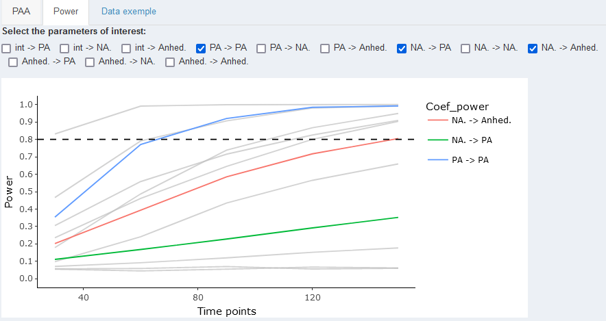

Power analysis VAR(1)

## Sensitivity analysis for power: varying parameters

We slightly changed the values of three coefficients to investigate how they change either the sample size recommendation or the precision of estimates:

- $\beta_{11} = .39$ to $\beta_{11} = .8$
- $\sigma_{00} = 90$ to $\sigma_{00} = 180$
- $R = 1000$ to $R = 100$

What conclusions can you draw based on the following power curves?

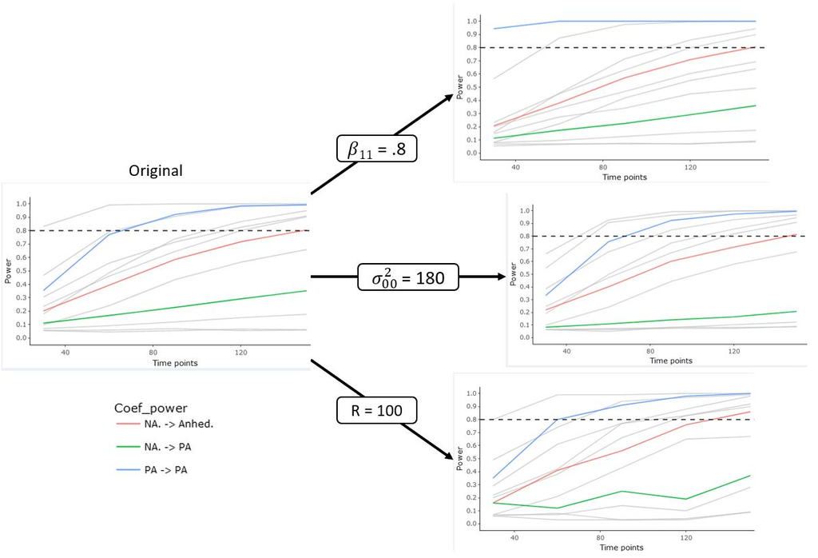

Sensitivity analysis for power

## Sensitivity analysis for power: using CI

Following Lafit, Revol et al. (under review), we run a sensitivity analysis using the upper and lower boundaries of the estimated coefficients of interest. First, we extract the 95% confidence interval of the estimated values of each parameter.

```r
# Linear regression model for PA
confint(fit.VAR.PA, level=0.95)
```

```
##                    2.5 %     97.5 %
## (Intercept)    9.5296021 35.6778667
## PA.lag         0.1208077  0.6605412
## NA.lag        -0.4063407  0.1530965
## anhedonia.lag -0.1488169  0.2600881
```

```r
# Linear regression model for NA
confint(fit.VAR.NA, level=0.95)
```

```
##                     2.5 %     97.5 %
## (Intercept)    1.46062438 28.2247622
## PA.lag        -0.30162831  0.2508175
## NA.lag        -0.06736614  0.5052475
## anhedonia.lag -0.01071022  0.4078257
```

```r
# Linear regression model for anhedonia
confint(fit.VAR.anhedonia, level=0.95)
```

```
##                     2.5 %     97.5 %
## (Intercept)   -2.97591249 32.8729333
## PA.lag        -0.32611856  0.4138472
## NA.lag        -0.05709339  0.7098859
## anhedonia.lag  0.02741213  0.5880142
```

We only varied the parameter values for the auto-regressive effect of PA ($\beta_{11}$) following the confidence interval. We run two new power analyses. The results are displayed below.  
What conclusions can you draw based on the following power curves?

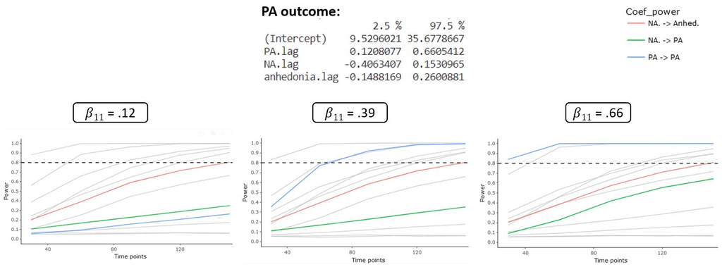

Sensitivity analysis for power

# Exercice: PAA of VAR(1) with 3 variables

## PAA result

Running the simulation with the application, you should end up with a similar plot:

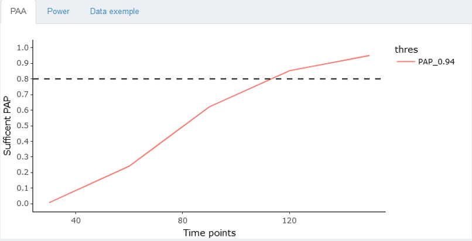

PAA for VAR(1)

## Sensitivity analysis for power: varying parameters

We changed the values of the transition matrix to investigate how it changes the sample size recommendation. What conclusions can you draw based on the following power curves?

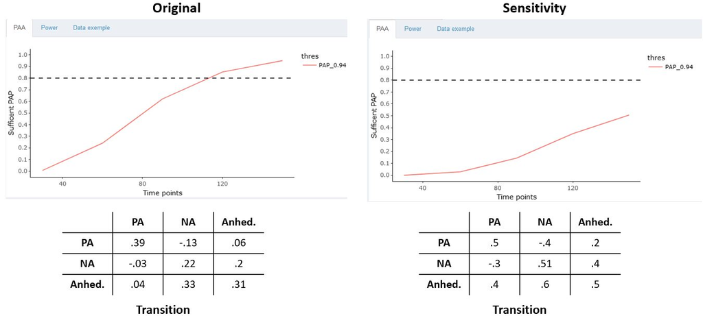

Sensitive PAA for VAR(1)

Note that, despites the raising of the coefficients, the new transition matrix still fulfills the stationary assumption. Higher coefficients could lead to a violation of this assumption.